# Coyotes Analysis

## Necessary Libraries

```r
# these libraries will be necessary to run the code throughout the document
library(tidyverse)
library(readxl)
library(nlme)
library(multcomp)
library(emmeans)
library(car)
library(multcompView)
```

The libraries in the code chunk above are essential to being able to run the code provided in this document. If you do not have the libraries previously installed, you will have to use the install.packages() function to do so. For example, if you do not have the package “tidyverse” downloaded, you will have to run code which looks like:

install.packages(“tidyverse”)

This can be done either in a code chunk or in the R console.

## Importing the Data

```r
# import each sheet from the excel file
# these sheets have correctly changed the extra "site 7" to "site 6" on both sheets
distance <- read_excel("Copy of coyotes.xlsx", sheet = "Distance")
behaviors <- read_excel("Copy of coyotes.xlsx", sheet = "Behaviors")
```

## Formatting the Data

Before running the analysis, we must ensure the data is formatted and cleaned properly. To do so, I have provided the code below which formats both the “distance” and “behaviors” sheets from the excel file which you had provided. One thing to note is that these sheets corrected the row which had put site 7 instead of site 6 for the last observation of footprint 1.

```r
# turn footprint, trial, and site variables to factor variables and clean variable names
# Total represents the total amount of time recorded in each video/row
# slice() removes the rows with NA values at the bottom of the sheet
distance <- distance %>%
  mutate_at(vars(Footprint, Trial, Site), as.factor) %>%
   rename(
    On = "Time Spent On Bait",
    Close = "Time Spent Close To Bait",
    Far = "Time Spent Far From Bait"
  ) %>%
  slice(-c(32:35))

head(distance)
```

```
# A tibble: 6 × 11
  Video Site  Footprint Trial     `Set-up Date`       `Date of Video`
  <dbl> <fct> <fct>     <fct>     <dttm>              <dttm>
1     1 1     1         Treatment 2022-07-30 00:00:00 2022-08-15 00:00:00
2     2 1     1         Treatment 2022-07-30 00:00:00 2022-08-16 00:00:00
3     3 1     1         Treatment 2022-12-09 00:00:00 2023-01-01 00:00:00
4     4 1     1         Treatment 2022-12-09 00:00:00 2022-12-11 00:00:00
5     5 2     1         Treatment 2022-12-09 00:00:00 2023-01-04 00:00:00
6     6 2     1         Treatment 2022-12-09 00:00:00 2023-01-05 00:00:00
# ℹ 5 more variables: DaysSinceDeployment <dbl>, Cover <dbl>, On <dbl>,
#   Close <dbl>, Far <dbl>
```

```r
# turn footprint, trial, and site variables to factor variables and clean variable names
# Total represents the total amount of time recorded in each video/row
behaviors <- behaviors %>%
  mutate_at(vars(Footprint, Trial, Site), as.factor) %>%
   rename(
    Vig = "Time Spent Vigilant",
    Inv = "Time Spent Investigative",
    Comf = "Time Spent Comfortable"
  )

head(behaviors)
```

```
# A tibble: 6 × 11
  Video Site  Footprint Trial     `Set-up Date`       `Date of Video`
  <dbl> <fct> <fct>     <fct>     <dttm>              <dttm>
1     1 1     1         Treatment 2022-07-30 00:00:00 2022-08-15 00:00:00
2     2 1     1         Treatment 2022-07-30 00:00:00 2022-08-16 00:00:00
3     3 1     1         Treatment 2022-12-09 00:00:00 2023-01-01 00:00:00
4     4 1     1         Treatment 2022-12-09 00:00:00 2022-12-11 00:00:00
5     5 2     1         Treatment 2022-12-09 00:00:00 2023-01-04 00:00:00
6     6 2     1         Treatment 2022-12-09 00:00:00 2023-01-05 00:00:00
# ℹ 5 more variables: DaysSinceDeployment <dbl>, Cover <dbl>, Vig <dbl>,
#   Inv <dbl>, Comf <dbl>
```

After formatting the data with the code above, the data should be ready for analysis.

## Analysis Overview

For the analysis of the “coyotes” data, we will be using the lme() function from the *nlme* package. This function fits **linear mixed-effects models**.

### What are linear mixed-effects models?

These models are meant to analyze data which are multilevel/hierarchical, non independent, longitudinal, or correlated. For the data you have collected, we will focus on the fact that it is **multilevel/hierarchical.**

By this, I mean that we have multiple video recordings for each site at both San Luis Obispo and Carrizo. This leads to the observations being non-independent, as we expect the recordings within one site to be more similar to each other than they are to the recordings from different sites.

This means that we have within-site variation and between-site variation, which we need to account for.

### Fixed and Random Effects

Being able to specify fixed and random effects is a major advantage of this model.

A **fixed** **effect** is something that is assumed to be constant among our population of interest. For example, we expect or assume that the effect of human footprint remains the same regardless of the site at which the recording occurs. To simplify fixed effects, these are often the effects we are interested in analyzing. So, as you had noted in our previous meeting, you are interested in how both footprint level and the presence/absence of a stool affect coyotes.

Thus, we will treat **Footprint** and **Trial** as **fixed effects** in our model.

A **random** **effect** is best described as uncontrollable variation in our data, often occurring from the multilevel structure as previously mentioned. To simplify random effects, these are often variables which have an effect on the data, but we are not interested in measuring that effect. In the coyotes data, *site* potentially affects the data by natural differences in things like the environment and the temperature, which we have no control over. As you had noted in our previous meeting, you are not interesting in seeing how coyotes’ “boldness” differs from site-to-site.

Thus, we will treat **Site** as a **random** **effect** in our model, so it knows to account for variation between sites.

### Interaction Effect

Another important thing to discuss regarding the analysis is the use of an interaction effect. In the model we will be using, we will specify an interaction effect between Footprint and Trial. Interpreting and understanding interaction effects can get tricky and complicated, even for graduate students like myself.

This is the best way I can think to describe an interaction effect between two variables:

**The effect of one predictor variable on the response variable is influenced by the value of the other predictor variable.**

So, in the context of the coyotes data, this is how an interaction could look. This example is not based on any analysis, it is just to explain an interaction.

Let’s say that for Carrizo (footprint level 1), the presence of a stool greatly affects coyotes. Without a stool, they are most likely to be on the bait, however, when a stool is present, they are most likely to stay far from the bait.

Now, for San Luis Obispo (footprint level 10), let’s say the presence of a stool does not affect coyotes, as they are used to humans and do not get scared as easily. Both with and without a stool, they are likely to be on the bait.

In this situation, we see that the effect of the stool (Trial) changes based on which location (Footprint) we are at. This would indicate an interaction effect between Trial and Footprint.

Now let’s say that in San Luis Obispo, the coyotes were likely to be on the bait without a stool and likely to be far from the bait with a stool. In this instance, the effect of the stool (Trial) would be the same for both Carrizo and San Luis Obispo, indicating that there is no evidence of an interaction effect between Trial and Footprint.

## Distance Models

The following code will show how to analyze the data from the “distance” sheet. This will provide a template for analyzing the data and interpreting the results. The “behaviors” sheet should be treated similarly.

The basic format for the models will be:

lme(**response** ~ Footprint * Trial, random = ~1|Site, data = **sheet**)

The **response** variable should be replaced with whichever column you are hoping to analyze. This could be time spent on bait, time spent close to bait, time spent far from bait, time spent vigilant, time spent comfortable, or time spent investigative.

The **sheet** option should be either *distance* or *behaviors*, depending on which sheet the response variable comes from.

Additionally, the * between Footprint and Trial indicates that we are interested in testing for an interaction effect. If we do not want to test for that effect, we should use a + instead of a *.

### Incorrect Analysis

The code below indicates incorrect analysis. Do not replicate this for your project. This is simply showing why we chose the final model, which will be shown after this.

```r
model_on <- lme(On ~ Footprint * Trial, random = ~1|Site, data = distance)
summary(model_on)
```

```
Linear mixed-effects model fit by REML
  Data: distance
       AIC      BIC    logLik
  249.5575 257.3325 -118.7787

Random effects:
 Formula: ~1 | Site
        (Intercept) Residual
StdDev:    11.05296 14.94388

Fixed effects:  On ~ Footprint * Trial
                                Value Std.Error DF    t-value p-value
(Intercept)                  5.774643  8.755087 18  0.6595758  0.5179
Footprint10                 18.589178 12.246126  9  1.5179640  0.1633
TrialTreatment              -1.266818 10.719940 18 -0.1181740  0.9072
Footprint10:TrialTreatment -18.588728 16.322511  9 -1.1388400  0.2842
 Correlation:
                           (Intr) Ftpr10 TrlTrt
Footprint10                -0.715
TrialTreatment             -0.737  0.527
Footprint10:TrialTreatment  0.484 -0.713 -0.657

Standardized Within-Group Residuals:
        Min          Q1         Med          Q3         Max
-1.00564436 -0.32934853 -0.12906024 -0.07837867  2.89908139

Number of Observations: 31
Number of Groups: 12
```

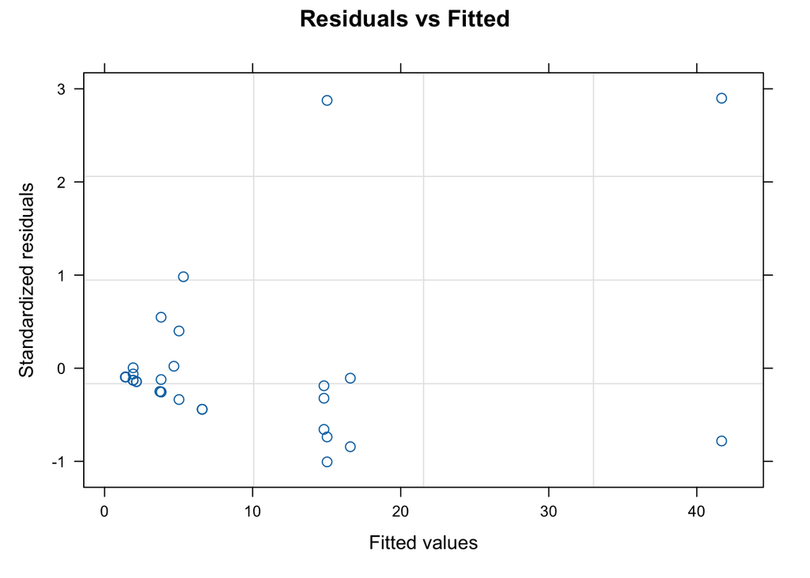

```r
# Check Model Assumptions
# Residuals vs. Fitted plot
plot(model_on, resid(., type = "p") ~ fitted(.), main = "Residuals vs Fitted")
```

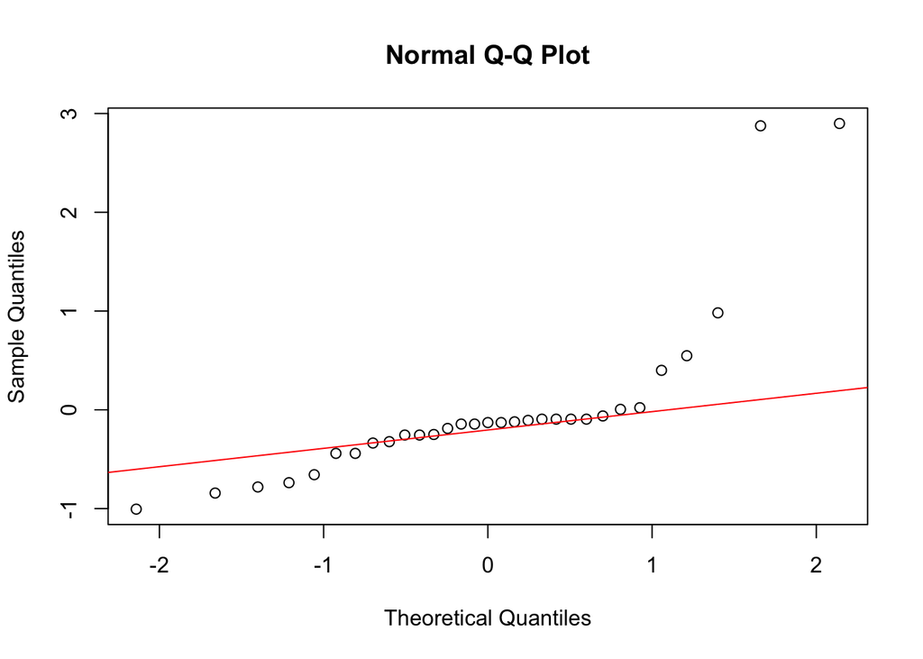

```r
# Normal Q-Q plot for residuals
qqnorm(residuals(model_on, type = "p"))
qqline(residuals(model_on, type = "p"), col = "red")
```

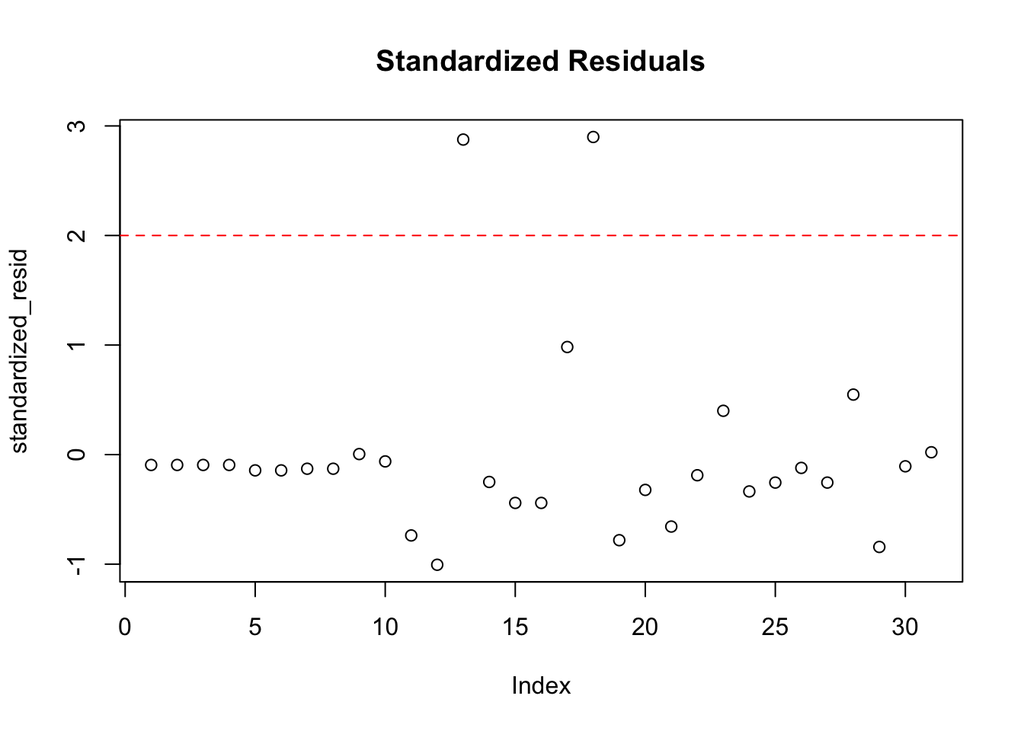

```r
# Standardized residuals
standardized_resid <- residuals(model_on, type = "pearson")

# Plot standardized residuals
plot(standardized_resid, main = "Standardized Residuals")
abline(h = c(-2, 2), col = "red", lty = 2)
```

From this initial analysis, we can see that there appears to be some fanning in the Residuals vs Fitted plot. This is not a good sign. Additionally, there is some curvature in the normal q-q plot. Ideally, we would want the dots to stay close to the red line.

Without getting into all the technical details, this indicates to us that we most likely have to transform the response variable. A popular method of doing this is to take the log of the response. This is done through the log() function. An advantage of this is that it can stabilize the variance in our data and deal with right-skewness in our response variable (which is the case in our data).

#### **Considerations of a Log Transformation**

Usually, in a linear model, the main effects can be interpreted as:

“After adjusting for all other predictors, for a one unit increase in x, we expect y to increase/decrease by ____ amount”

This means that the coefficient estimates for our explanatory variables usually have an additive effect. However, with a log transformation, now they have a multiplicative effect.

In our model, the log transformation will look like **log(response + 1).** The “+1” just makes sure that there are no 0 values.

To deal with and interpret a coefficient estimate in a log-transformed model, we need to exponentiate our coefficient estimate.

For example, let’s say the coefficient estimate for Footprint is .5 on the log scale and Footprint level 1 is our reference level.

```r
# back transform the log-scale coefficient estimate
exp(.5)
```

```
[1] 1.648721
```

After back-transforming, we have a new estimate of 1.65. We can interpret this by saying:

“When Footprint changes from level 1 to level 10, and Trial is held constant at its reference level (Baseline), the expected time spent on bait is multiplied by 1.65.”

```r
# turn back-transformed estimate into a percentage
(1.65 - 1) * 100
```

```
[1] 65
```

Instead of using the idea of multiplication, we can also speak about the effect in terms of its percentages.

“When Footprint changes from level 1 to level 10, and Trial is held constant at its reference level (Baseline), the expected time on bait increases by 65 percent.”

### Analysis with log of response

### On Bait

```r
# specify the model with an interaction
model_log_on <- lme(log(On + 1) ~ Footprint * Trial, random = ~1|Site, data = distance)
```

```r
# get model summary and check coefficient estimates
summary(model_log_on)
```

```
Linear mixed-effects model fit by REML
  Data: distance
       AIC      BIC    logLik
  104.8914 112.6664 -46.44568

Random effects:
 Formula: ~1 | Site
         (Intercept) Residual
StdDev: 8.590194e-05 1.163712

Fixed effects:  log(On + 1) ~ Footprint * Trial
                                Value Std.Error DF    t-value p-value
(Intercept)                 0.9478292 0.4750834 18  1.9950797  0.0614
Footprint10                 1.7700230 0.6474295  9  2.7339238  0.0231
TrialTreatment             -0.5081672 0.5906061 18 -0.8604164  0.4009
Footprint10:TrialTreatment -1.0753667 0.8577512  9 -1.2537047  0.2415
 Correlation:
                           (Intr) Ftpr10 TrlTrt
Footprint10                -0.734
TrialTreatment             -0.804  0.590
Footprint10:TrialTreatment  0.554 -0.755 -0.689

Standardized Within-Group Residuals:
       Min         Q1        Med         Q3        Max
-0.9747415 -0.8051486 -0.3778100  0.5656003  2.6894185

Number of Observations: 31
Number of Groups: 12
```

```r
# check statistical significance of model effects
Anova(model_log_on, type = "III")
```

```
Analysis of Deviance Table (Type III tests)

Response: log(On + 1)
                 Chisq Df Pr(>Chisq)
(Intercept)     3.9803  1   0.046034 *
Footprint       7.4743  1   0.006258 **
Trial           0.7403  1   0.389560
Footprint:Trial 1.5718  1   0.209949
---
Signif. codes:  0 '***' 0.001 '**' 0.01 '*' 0.05 '.' 0.1 ' ' 1
```

From the Anova output, we see that Footprint has a statistically significant effect on the coyotes’ time spent on bait. This is seen through the p-value of .006, which is less than .05. However, Trial and the interaction effect between Footprint and Trial do not seem to have a statistically significant effect on the coyotes’ time spent on bait.

```r
# model without the interaction
model_log_on_2 <- lme(log(On + 1) ~ Footprint + Trial, random = ~1|Site, data = distance)
Anova(model_log_on_2, type = "II")
```

```
Analysis of Deviance Table (Type II tests)

Response: log(On + 1)
           Chisq Df Pr(>Chisq)
Footprint 7.2782  1    0.00698 **
Trial     5.5363  1    0.01863 *
---
Signif. codes:  0 '***' 0.001 '**' 0.01 '*' 0.05 '.' 0.1 ' ' 1
```

```r
summary(model_log_on_2)
```

```
Linear mixed-effects model fit by REML
  Data: distance
       AIC      BIC    logLik
  105.9884 112.6494 -47.99418

Random effects:
 Formula: ~1 | Site
         (Intercept) Residual
StdDev: 5.333491e-05 1.175534

Fixed effects:  log(On + 1) ~ Footprint + Trial
                   Value Std.Error DF   t-value p-value
(Intercept)     1.277723 0.3995740 18  3.197712  0.0050
Footprint10     1.157364 0.4289998 10  2.697819  0.0224
TrialTreatment -1.018002 0.4326510 18 -2.352942  0.0302
 Correlation:
               (Intr) Ftpr10
Footprint10    -0.578
TrialTreatment -0.701  0.148

Standardized Within-Group Residuals:
       Min         Q1        Med         Q3        Max
-1.2054814 -0.6248122 -0.2209381  0.3437173  2.3817394

Number of Observations: 31
Number of Groups: 12
```

Without the interaction term, the model becomes much simpler and is easier to interpret. Additionally, we can see that now, both Footprint and Trial are statistically significant in terms of their effect on the time spent on bait.

From the third panel, the coefficient estimates on the log-scale are:

- Footprint(10) : 1.157
- Trial(Treatment) : -1.018

```r
# back transform the log-scale coefficient estimates
exp(1.157)
```

```
[1] 3.180378
```

```r
exp(-1.018)
```

```
[1] 0.3613169
```

```r
# change estimates to percentages
(3.18 - 1) * 100
```

```
[1] 218
```

```r
(.36 - 1) * 100
```

```
[1] -64
```

After back-transforming, these coefficient estimates are now:

- Footprint(10): 3.18
- Trial(Treatment): .36

Here is how we can interpret these estimates:

- Footprint
  - When holding Trial (stool/no stool) constant, a footprint of level 10 (Slo) is associated with multiplying the expected time (seconds) spent on bait by 3.18 compared to a footprint level of 1 (Carrizo).
  - When holding Trial (stool/no stool) constant, a footprint of level 10 (Slo) is associated with increasing the expected time (seconds) spent on bait by 218% compared to a footprint level of 1 (Carrizo).
- Trial
  - When holding Footprint (Carrizo, Slo) constant, the presence of a stool is associated with multiplying the expected time (seconds) spent on bait by .36 compared to when there is no stool.
  - When holding Footprint (Carrizo, Slo) constant, the presence of a stool is associated with decreasing the expected time (seconds) spent on bait by 64% compared to when there is no stool.

### Predicted Time Spent on Bait

Another way to look at the results of the model is through the emmeans() function, which shows the predicted responses for different levels of our categorical explanatory variables.

```r
emmeans_both <- emmeans(model_log_on_2, ~ Footprint + Trial, type = "response")
summary(emmeans_both)
```

```
 Footprint Trial     response    SE df lower.CL upper.CL
 1         Baseline     2.588 1.434 11    0.489     7.65
 10        Baseline    10.417 4.355 10    3.880    25.71
 1         Treatment    0.297 0.419 11   -0.364     1.64
 10        Treatment    3.125 1.573 10    0.763     8.65

Degrees-of-freedom method: containment
Confidence level used: 0.95
Intervals are back-transformed from the log(mu + 1) scale
```

```r
# get pairwise comparisons
pairs(emmeans_both, type = "response")
```

```
 contrast                                     estimate    SE df t.ratio p.value
 Footprint1 Baseline - Footprint10 Baseline     -1.157 0.429 10  -2.698  0.0885
 Footprint1 Baseline - Footprint1 Treatment      1.018 0.433 18   2.353  0.1229
 Footprint1 Baseline - Footprint10 Treatment    -0.139 0.653 10  -0.213  0.9963
 Footprint10 Baseline - Footprint1 Treatment     2.175 0.562 10   3.869  0.0139
 Footprint10 Baseline - Footprint10 Treatment    1.018 0.433 18   2.353  0.1229
 Footprint1 Treatment - Footprint10 Treatment   -1.157 0.429 10  -2.698  0.0885

Note: contrasts are still on the log(mu + 1) scale
Degrees-of-freedom method: containment
P value adjustment: tukey method for comparing a family of 4 estimates
```

For example, we can look at the combinations of footprint and trial.

For each coyote appearance in Carrizo (footprint level 1) and without the presence of a stool, the predicted amount of time spent on bait is 2.588 seconds.

```r
emmeans_trial <- emmeans(model_log_on_2, ~ Trial, type = "response")
emmeans_trial
```

```
 Trial     response   SE df lower.CL upper.CL
 Baseline      5.40 2.09 10    2.093    12.25
 Treatment     1.31 0.65 10    0.236     3.33

Results are averaged over the levels of: Footprint
Degrees-of-freedom method: containment
Confidence level used: 0.95
Intervals are back-transformed from the log(mu + 1) scale
```

```r
pairs(emmeans_trial, type = "response")
```

```
 contrast             estimate    SE df t.ratio p.value
 Baseline - Treatment     1.02 0.433 18   2.353  0.0302

Results are averaged over the levels of: Footprint
Note: contrasts are still on the log(mu + 1) scale
Degrees-of-freedom method: containment
```

```r
emmeans_footprint <- emmeans(model_log_on_2, ~ Footprint, type = "response")
emmeans_footprint
```

```
 Footprint response   SE df lower.CL upper.CL
 1             1.16 0.63 11    0.134      3.1
 10            5.86 2.16 10    2.408     12.8

Results are averaged over the levels of: Trial
Degrees-of-freedom method: containment
Confidence level used: 0.95
Intervals are back-transformed from the log(mu + 1) scale
```

```r
pairs(emmeans_footprint, type = "response")
```

```
 contrast                 estimate    SE df t.ratio p.value
 Footprint1 - Footprint10    -1.16 0.429 10  -2.698  0.0224

Results are averaged over the levels of: Trial
Note: contrasts are still on the log(mu + 1) scale
Degrees-of-freedom method: containment
```

We can also look at the explanatory variables individually, which is shown with the two code chunks above. This just shows the predicted amount of time spent on bait for each level of footprint or trial.

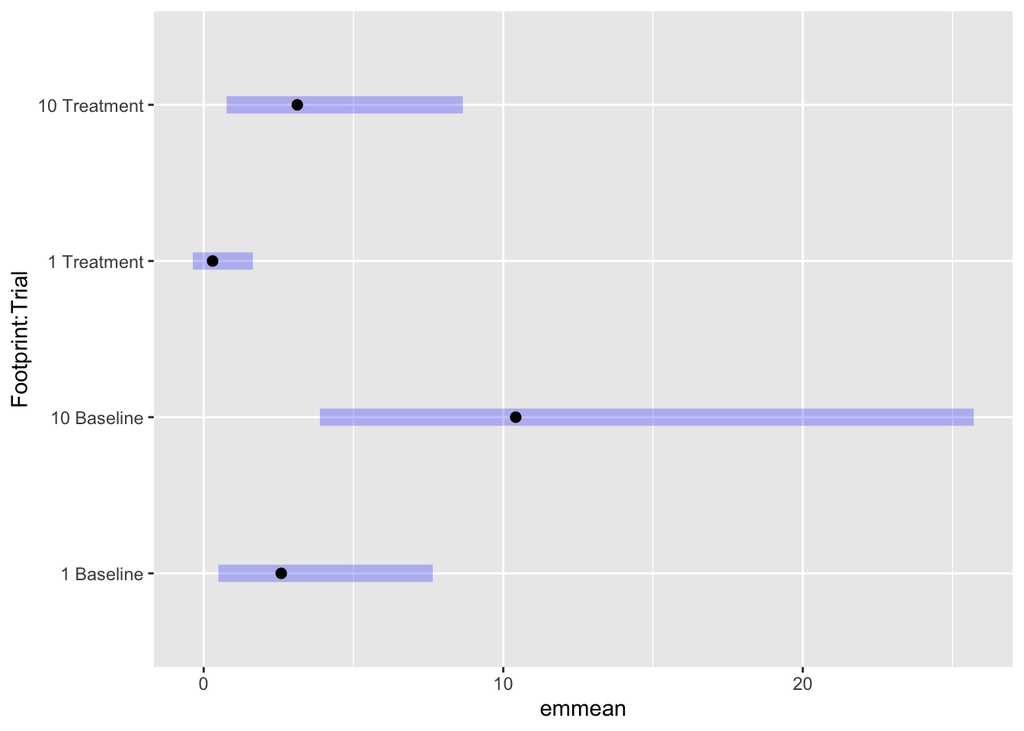

```r
# plot the predicted responses
plot(emmeans_both)
```

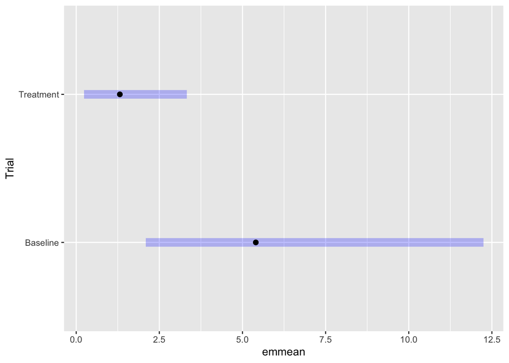

```r
plot(emmeans_trial)
```

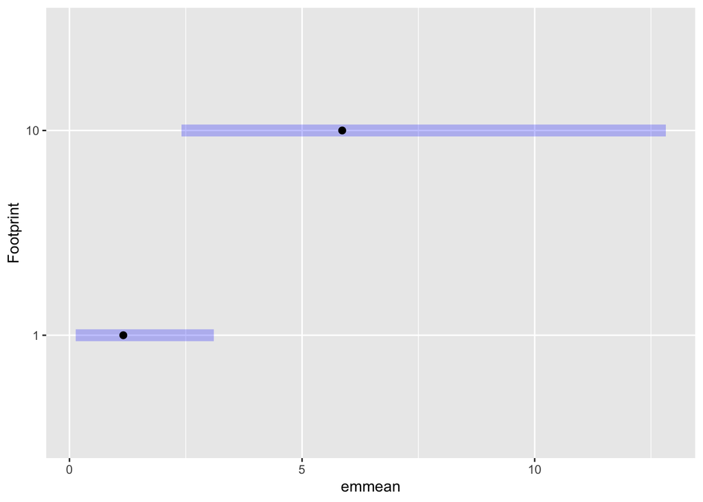

```r
plot(emmeans_footprint)
```

## Generalizability

We are only able to generalize the results of this data to the population from which it came from, as well as any situations or scenarios which may be nearly identical. For example, because the areas of Slo and Carrizo were used, we can only generalize these results to the areas of Slo and Carrizo, or any areas which have similar 1 and 10 footprint levels and similar characteristics in terms of the environment. However, we should be cautious if trying to generalize outside of Slo and Carrizo. Additionally, we must consider the fact that the presence/absence of a stool was used as a factor, and we cannot assume the results would be the same if a different object was used.

Regarding the other analysis, I recommend modeling the other response variables in a near identical fashion to what I have just shown. I don’t believe an interaction effect should be used in these models, as I did not find any significant interaction effects in any of the models when I tested them. A basic set-up of the other models are in the code chunks below, but you should add code to back-transform the estimates and to find the predicted responses which we went over previously.

## Other Analysis

### Time Spent Close to Bait

```r
model_close <- lme(log(Close + 1) ~ Footprint + Trial, random = ~1|Site, data = distance)
Anova(model_close, type = "II")
```

```
Analysis of Deviance Table (Type II tests)

Response: log(Close + 1)
           Chisq Df Pr(>Chisq)
Footprint 2.4465  1     0.1178
Trial     2.4904  1     0.1145
```

```r
summary(model_close)
```

```
Linear mixed-effects model fit by REML
  Data: distance
       AIC      BIC    logLik
  95.41332 102.0743 -42.70666

Random effects:
 Formula: ~1 | Site
        (Intercept)  Residual
StdDev:   0.2182929 0.9543448

Fixed effects:  log(Close + 1) ~ Footprint + Trial
                   Value Std.Error DF  t-value p-value
(Intercept)    1.2043413 0.3454893 18 3.485901  0.0026
Footprint10    0.5843773 0.3736107 10 1.564134  0.1489
TrialTreatment 0.5896344 0.3736344 18 1.578105  0.1320
 Correlation:
               (Intr) Ftpr10
Footprint10    -0.584
TrialTreatment -0.690  0.144

Standardized Within-Group Residuals:
       Min         Q1        Med         Q3        Max
-1.7856669 -0.5288522  0.1861732  0.6079518  2.2973917

Number of Observations: 31
Number of Groups: 12
```

### Time Spent Far from Bait

```r
model_log_far <- lme(log(Far + 1) ~ Footprint + Trial, random = ~1|Site, data = distance)
Anova(model_log_far, type = "II")
```

```
Analysis of Deviance Table (Type II tests)

Response: log(Far + 1)
           Chisq Df Pr(>Chisq)
Footprint 5.3669  1    0.02052 *
Trial     1.5800  1    0.20876
---
Signif. codes:  0 '***' 0.001 '**' 0.01 '*' 0.05 '.' 0.1 ' ' 1
```

```r
summary(model_log_far)
```

```
Linear mixed-effects model fit by REML
  Data: distance
      AIC      BIC    logLik
  91.4607 98.12172 -40.73035

Random effects:
 Formula: ~1 | Site
        (Intercept)  Residual
StdDev:   0.4571809 0.8295491

Fixed effects:  log(Far + 1) ~ Footprint + Trial
                    Value Std.Error DF   t-value p-value
(Intercept)     1.5465928 0.3714744 18  4.163390  0.0006
Footprint10    -0.9511021 0.4105476 10 -2.316667  0.0430
TrialTreatment  0.4992799 0.3972023 18  1.256991  0.2248
 Correlation:
               (Intr) Ftpr10
Footprint10    -0.597
TrialTreatment -0.656  0.125

Standardized Within-Group Residuals:
       Min         Q1        Med         Q3        Max
-2.0389185 -0.5534525  0.2311171  0.7619653  1.5546411

Number of Observations: 31
Number of Groups: 12
```

### Time Spent Vigilant

```r
model_vigilant <- lme(log(Vig + 1) ~ Footprint + Trial, random = ~1|Site, data = behaviors)
Anova(model_vigilant, type = "II")
```

```
Analysis of Deviance Table (Type II tests)

Response: log(Vig + 1)
           Chisq Df Pr(>Chisq)
Footprint 2.4579  1     0.1169
Trial     0.0593  1     0.8075
```

```r
summary(model_vigilant)
```

```
Linear mixed-effects model fit by REML
  Data: behaviors
       AIC      BIC    logLik
  93.81374 100.4748 -41.90687

Random effects:
 Formula: ~1 | Site
        (Intercept)  Residual
StdDev:   0.7726002 0.7770732

Fixed effects:  log(Vig + 1) ~ Footprint + Trial
                    Value Std.Error DF   t-value p-value
(Intercept)     1.7251388 0.4717052 18  3.657239  0.0018
Footprint10    -0.8454882 0.5392986 10 -1.567755  0.1480
TrialTreatment  0.1183284 0.4857664 18  0.243591  0.8103
 Correlation:
               (Intr) Ftpr10
Footprint10    -0.609
TrialTreatment -0.608  0.094

Standardized Within-Group Residuals:
       Min         Q1        Med         Q3        Max
-1.4542789 -0.7968720  0.1678563  0.5640017  1.6074340

Number of Observations: 31
Number of Groups: 12
```

### Time Spent Comfortable

```r
model_comf <- lme(log(Comf + 1) ~ Footprint + Trial, random = ~1|Site, data = behaviors)
Anova(model_comf, type = "II")
```

```
Analysis of Deviance Table (Type II tests)

Response: log(Comf + 1)
            Chisq Df Pr(>Chisq)
Footprint 25.9288  1  3.542e-07 ***
Trial      2.8861  1    0.08934 .
---
Signif. codes:  0 '***' 0.001 '**' 0.01 '*' 0.05 '.' 0.1 ' ' 1
```

```r
summary(model_comf)
```

```
Linear mixed-effects model fit by REML
  Data: behaviors
       AIC      BIC    logLik
  97.75733 104.4183 -43.87866

Random effects:
 Formula: ~1 | Site
         (Intercept) Residual
StdDev: 2.838764e-05 1.014849

Fixed effects:  log(Comf + 1) ~ Footprint + Trial
                    Value Std.Error DF   t-value p-value
(Intercept)     0.8259611 0.3449557 18  2.394397  0.0277
Footprint10     1.8858810 0.3703593 10  5.092031  0.0005
TrialTreatment -0.6345458 0.3735114 18 -1.698866  0.1066
 Correlation:
               (Intr) Ftpr10
Footprint10    -0.578
TrialTreatment -0.701  0.148

Standardized Within-Group Residuals:
        Min          Q1         Med          Q3         Max
-0.96436456 -0.59398982 -0.18861461  0.02806071  3.09832518

Number of Observations: 31
Number of Groups: 12
```

### Time Spent Investigative

```r
model_inv <- lme(log(Inv + 1) ~ Footprint + Trial, random = ~1|Site, data = behaviors)
Anova(model_inv, type = "II")
```

```
Analysis of Deviance Table (Type II tests)

Response: log(Inv + 1)
           Chisq Df Pr(>Chisq)
Footprint 0.9561  1     0.3282
Trial     0.5306  1     0.4664
```

```r
summary(model_inv)
```

```
Linear mixed-effects model fit by REML
  Data: behaviors
       AIC      BIC    logLik
  98.88557 105.5466 -44.44279

Random effects:
 Formula: ~1 | Site
        (Intercept)  Residual
StdDev:   0.3448789 0.9930716

Fixed effects:  log(Inv + 1) ~ Footprint + Trial
                   Value Std.Error DF   t-value p-value
(Intercept)    1.1890104 0.3854472 18 3.0847553  0.0064
Footprint10    0.4105717 0.4198878 10 0.9778129  0.3512
TrialTreatment 0.3028656 0.4158002 18 0.7283921  0.4757
 Correlation:
               (Intr) Ftpr10
Footprint10    -0.589
TrialTreatment -0.679  0.138

Standardized Within-Group Residuals:
        Min          Q1         Med          Q3         Max
-1.84791933 -0.61470588 -0.07623962  0.78510812  1.37093509

Number of Observations: 31
Number of Groups: 12
```

## P-value adjustment

One thing to take into consideration is an adjustment method for multiple comparisons to control the family-wise error rate. This is done when we are conducting multiple hypothesis tests. In this instance, because there are 6 models and we are essentially testing for 2 effects each time (Footprint and Trial), we have 12 tests (p-values).

Often, we want to account for this through some form of adjustment, as this will help us decrease the chances of incorrectly assuming significance in a situation where there is none.

To do this, we could put all of the p-values into a vector and use the p.adjust() function, choosing a method of “bonferroni” or “BH” for Benjamini-Hochberg.

```r
# Example p-values from 12 hypothesis tests
p.values <- c(0.01, 0.04, 0.03, 0.05, 0.02, 0.01, 0.07, 0.06, 0.04, 0.05, 0.02, 0.03)

# Adjust p-values using Bonferroni correction
p.adjusted_bonferroni <- p.adjust(p.values, method = "bonferroni")
p.adjusted_bonferroni
```

```
 [1] 0.12 0.48 0.36 0.60 0.24 0.12 0.84 0.72 0.48 0.60 0.24 0.36
```

```r
# Adjust p-values using Benjamini-Hochberg correction
p.adjusted_bh <- p.adjust(p.values, method = "BH")
p.adjusted_bh
```

```
 [1] 0.06000000 0.06000000 0.06000000 0.06000000 0.06000000 0.06000000
 [7] 0.07000000 0.06545455 0.06000000 0.06000000 0.06000000 0.06000000
```

Alternatively, we could choose to test the effects with a smaller alpha level, such as .01 instead of .05. This would reduce the power of our tests and increase the chance of Type II errors (False Negatives).

## Conclusion

Overall, I hope this document provides sufficient help to analyze and interpret the coyotes data. A thorough example and description of modeling the time spent on bait was discussed, which should provide a template for the analysis of the other 5 responses. With that being said, if you do have any questions, please feel free to reach out and email me, and I will try to help you as quick as I can!